# Missing Stock Price

**Problem Description:**

**A time series of a stock's highest price during a trading day (at the New York Stock Exchange), is provided to you. In each test case, the day's highest prices is missing for certain days. By analyzing the data, try to identify the missing price for those particular days.**

**Records/Data:**

**In this problem, we have 10 cases/sets/bins of stock data, each case contains days between 146 and 250. There are 20 missing days within each case**

**Criteria for Scoring:**

**Compute the mean of the magnitude of the percentage difference between predicted price and the actual stock price, for each of the missing records in each case.**

**d = Average of abs((expected price - computed price)/expected price) x 100 (for all missing records, in all test cases).**

**The final score on a scale of 100 will be: 50 x max(2 - d, 0)**

**i.e, if the mean value of 'd' exceed 2% (your predictions are off by 2% or more on an average) you will score a zero.**

**Let's import the libraries first.**

```python
import numpy as np
from scipy import interpolate
import fileinput
import matplotlib.pyplot as plt
from sklearn.model_selection import cross_val_score
from sklearn.metrics import mean_squared_error
from sklearn.linear_model import Ridge
from sklearn.preprocessing import PolynomialFeatures
from sklearn.pipeline import make_pipeline
from sklearn.model_selection import train_test_split
```

**During the submission, I find that the online score calculating system has some problem. No matter how I change the model, the final score is always 1.16 (out of 100), which is not reasonable. So let's download the whole data and analyze them.**

```python
def Calculate_avg_score(d0,d1,d2,d3,d4,d5,d6,d7,d8,d9):
    d_average = (d0+d1+d2+d3+d4+d5+d6+d7+d8+d9)/10
    score = 50 * max(2 - d_average, 0)
    print('The score is: {0}'.format(score))
    return score
```

**First, let's input the data. The data contain the input parts labeled as input00.txt up to input09.txt. There are dates and true labels within the file. The missing labels start with "Missing_".**

**The data also contain the true values of the missing labels in labels00.txt up to labels09.txt**

**To build a predictive model using the available data, it is crucial to find out how the model utilizes the data through the online system. When I hit "Run code" not "Submit" button, my model is run against three separate cases, one case at a time. What the model does is that it uses the non-missing labels in that case to train the model, and then predicts the missing labels within the same case. To verify this, I hit "Submit" button. Although the number of cases increases from 3 to 10, the predicted labels within the first 3 cases are all the same as the values obtained after I hit "Run code". This indicates that the model only utilizes the training data within one case, not all 10 cases. It is crucial for improving the model later on.**

**Now let's extract the data case by case and train some models and conduct predictions on the testing data (missing labels) to see what the score will be.**

```python
#Function for extracting raw data and separate them into training data and testing data. Testing data are true labels for scoring.

def Extract_values(number):

    i=-1
    prices = []
    training_feature = []#training feature are univariate numbers such as 0, 1, 2, ...249
    training_label = []#training labels are non-missing labels
    testing_feature = []#testing features are univariate numbers with the labels missing
    testing_label = []#testing labels are true labels for missing labels, used for scoring the model
    total_label = []#all labels including missing and non-missing ones, used for plotting
    with open("C:/case/input/input0"+str(number)+".txt",'r') as file:
        for line in file:
            if i==-1:
                n=int(line)
                i=i+1
            else:
                prices.append(line.rstrip().split("\t")[1])
    with open("C:/case/input/labels0"+str(number)+".txt",'r') as file:
        for line in file:
            testing_label.append(float(line.rstrip()))

    j = 0
    for i in range(n):
        if not "Missing" in prices[i]:
            training_feature.append(i)
            training_label.append(float(prices[i]))
            total_label.append(float(prices[i]))
        else:
            testing_feature.append(i)
            total_label.append(testing_label[j])
            j+=1


    return training_feature, training_label, testing_feature, testing_label, total_label
```

```python
#Extracting features and labels
training_feature0, training_label0, testing_feature0, testing_label0, total_label0 = Extract_values(0)
training_feature1, training_label1, testing_feature1, testing_label1, total_label1 = Extract_values(1)
training_feature2, training_label2, testing_feature2, testing_label2, total_label2 = Extract_values(2)
training_feature3, training_label3, testing_feature3, testing_label3, total_label3 = Extract_values(3)
training_feature4, training_label4, testing_feature4, testing_label4, total_label4 = Extract_values(4)
training_feature5, training_label5, testing_feature5, testing_label5, total_label5 = Extract_values(5)
training_feature6, training_label6, testing_feature6, testing_label6, total_label6 = Extract_values(6)
training_feature7, training_label7, testing_feature7, testing_label7, total_label7 = Extract_values(7)
training_feature8, training_label8, testing_feature8, testing_label8, total_label8 = Extract_values(8)
training_feature9, training_label9, testing_feature9, testing_label9, total_label9 = Extract_values(9)
```

# Step 1: Ridge (Polynomial) Regression

**It is straight-forward to come up with a regression model for the data. There are linear model and polynomial model that can be used. I choose polynomial model at this time. I also add a penalty term to overcome overfitting problem and make it as a ridge regression. Lasso regression will be the same.**

**To visualize the results, let's plot two figures for a single case, the first figure contains the dots indicating the predicted missing labels and the true values (20 dots in one case). The second figure indicates the whole trend of the regressed line through all the data.**

```python
def Evaluate_regression(training_feature, training_label, testing_feature, testing_label, total_label, number, deg=2):

    from sklearn.linear_model import Ridge
    from sklearn.preprocessing import PolynomialFeatures
    from sklearn.pipeline import make_pipeline

    model = make_pipeline(PolynomialFeatures(deg), Ridge())#For ridge regression, let's try a default 2 degree polynomial model
    model.fit(np.reshape(training_feature,(-1,1)), training_label)
    predicting_label = model.predict(np.reshape(testing_feature,(-1,1)))

    if number in [0,1]:
        n = 250
    else:
        n = 146

    #plotting the figure for prediction-true label comparison
    x = np.arange(1,21,1)
    plt.subplot(2,1,1)
    plt.plot( x, predicting_label, x, testing_label,linewidth=4)
    plt.legend(['predicting_label'+str(number), 'testing_label'+str(number)], loc='lower left')
    plt.xticks(np.arange(1, 21, 1))

    #plotting the figure for whole data set
    i = np.linspace(0, n, num=500, endpoint=False)
    j = np.linspace(0, n, num=n, endpoint=False)
    plt.subplot(2,1,2)
    plt.plot( j, total_label,'go', i, model.predict(np.reshape(i,(-1,1))),'r', linewidth=1)
    plt.legend(['all_label'+str(number), 'predicting_line'+str(number)], loc='lower left')

    #calculating average score within each case,
    #e.g.,  mean of the magnitude of the percentage difference between predicted price and the actual stock price
    d = 0
    for i in range(20):
        d+=(abs(testing_label[i]-predicting_label[i])/testing_label[i])*100
    d/=20
    plt.show()

    return d
```

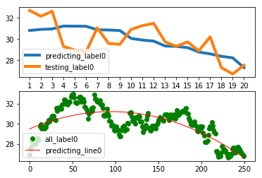

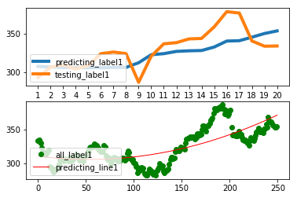

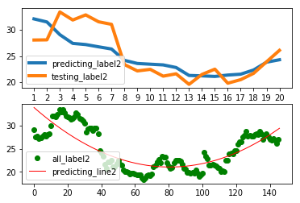

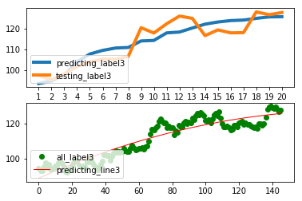

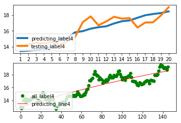

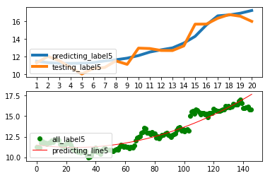

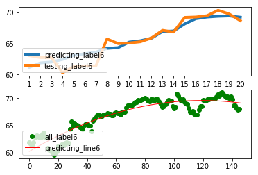

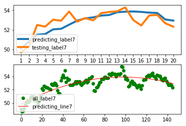

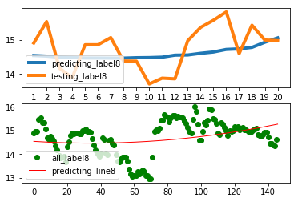

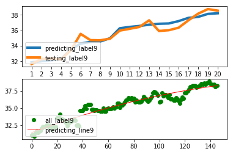

```python
d0 = Evaluate_regression(training_feature0, training_label0, testing_feature0, testing_label0, total_label0, 0)
d1 = Evaluate_regression(training_feature1, training_label1, testing_feature1, testing_label1, total_label1,1)
d2 = Evaluate_regression(training_feature2, training_label2, testing_feature2, testing_label2, total_label2,2)
d3 = Evaluate_regression(training_feature3, training_label3, testing_feature3, testing_label3, total_label3,3)
d4 = Evaluate_regression(training_feature4, training_label4, testing_feature4, testing_label4, total_label4,4)
d5 = Evaluate_regression(training_feature5, training_label5, testing_feature5, testing_label5, total_label5,5)
d6 = Evaluate_regression(training_feature6, training_label6, testing_feature6, testing_label6, total_label6,6)
d7 = Evaluate_regression(training_feature7, training_label7, testing_feature7, testing_label7, total_label7,7)
d8 = Evaluate_regression(training_feature8, training_label8, testing_feature8, testing_label8, total_label8,8)
d9 = Evaluate_regression(training_feature9, training_label9, testing_feature9, testing_label9, total_label9,9)
```

**By looking at the figures, it is clear that the ridge regression lines capture the major trends within each case, the lines are fitted by searching the minimum MSE. However, it is faily weak at predicting the missing labels. It has low ability to find out the missing dots.**

**The final score based on the comparison between the testing data and the predicted data is: 0. It means the predictions are off by 2% or more on an average.**

```python
#calculating the final score for the 10 cases

d_avg = (d0+d1+d2+d3+d4+d5+d6+d7+d8+d9)/10
score = 50 * max(2 - d_avg, 0)
print('The score for ridge regression with default settings is: {0}'.format(score))
```

```
The score for ridge regression with default settings is: 0
```

**Let's try some other degrees of the polynomial term, how about 10?**

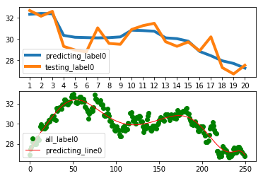

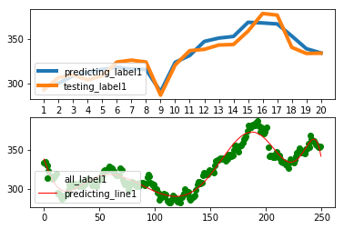

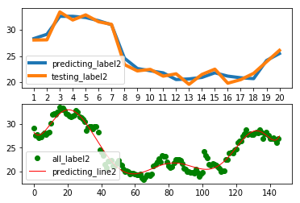

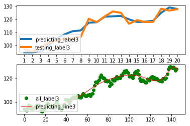

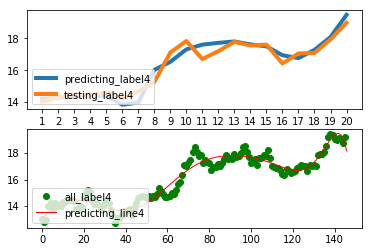

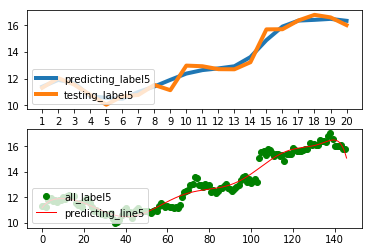

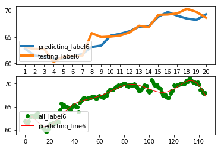

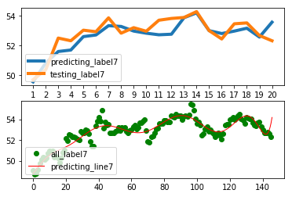

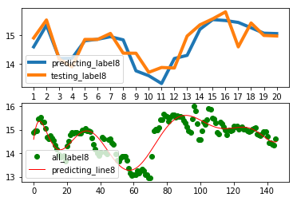

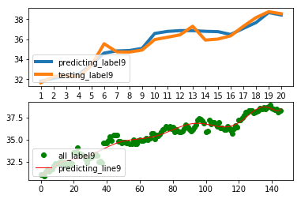

```python
d0 = Evaluate_regression(training_feature0, training_label0, testing_feature0, testing_label0, total_label0, 0, 10)
d1 = Evaluate_regression(training_feature1, training_label1, testing_feature1, testing_label1, total_label1,1, 10)
d2 = Evaluate_regression(training_feature2, training_label2, testing_feature2, testing_label2, total_label2,2, 10)
d3 = Evaluate_regression(training_feature3, training_label3, testing_feature3, testing_label3, total_label3,3, 10)
d4 = Evaluate_regression(training_feature4, training_label4, testing_feature4, testing_label4, total_label4,4, 10)
d5 = Evaluate_regression(training_feature5, training_label5, testing_feature5, testing_label5, total_label5,5, 10)
d6 = Evaluate_regression(training_feature6, training_label6, testing_feature6, testing_label6, total_label6,6, 10)
d7 = Evaluate_regression(training_feature7, training_label7, testing_feature7, testing_label7, total_label7,7, 10)
d8 = Evaluate_regression(training_feature8, training_label8, testing_feature8, testing_label8, total_label8,8, 10)
d9 = Evaluate_regression(training_feature9, training_label9, testing_feature9, testing_label9, total_label9,9, 10)
```

**The regression lines are more close to the data, the score should be higher.**

**The final score is 9.57, better than the default setting.**

```python
#calculating the final score for the 10 cases

d_avg = (d0+d1+d2+d3+d4+d5+d6+d7+d8+d9)/10
score = 50 * max(2 - d_avg, 0)
print('The score for ridge regression with degree=10 is: {0}'.format(score))
```

```
The score for ridge regression with degree=10 is: 9.566440420544565
```

**Let's try degree=20.**

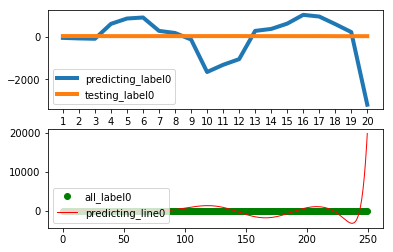

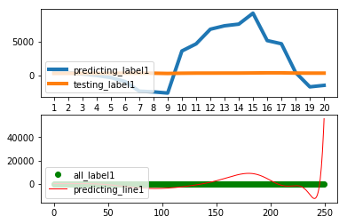

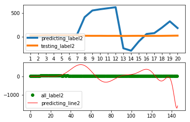

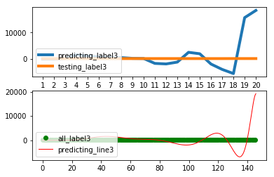

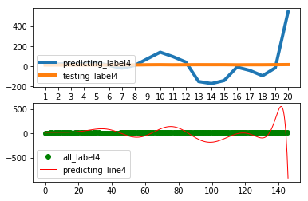

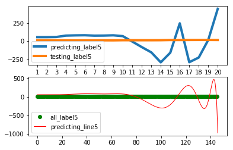

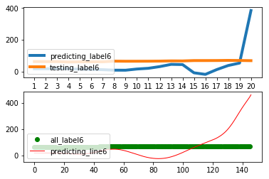

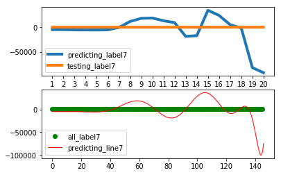

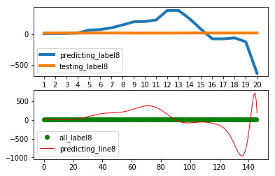

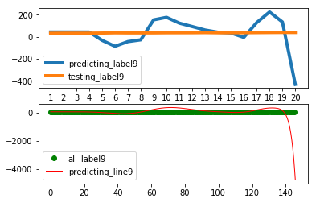

```python
d0 = Evaluate_regression(training_feature0, training_label0, testing_feature0, testing_label0, total_label0, 0, 20)
d1 = Evaluate_regression(training_feature1, training_label1, testing_feature1, testing_label1, total_label1,1, 20)
d2 = Evaluate_regression(training_feature2, training_label2, testing_feature2, testing_label2, total_label2,2, 20)
d3 = Evaluate_regression(training_feature3, training_label3, testing_feature3, testing_label3, total_label3,3, 20)
d4 = Evaluate_regression(training_feature4, training_label4, testing_feature4, testing_label4, total_label4,4, 20)
d5 = Evaluate_regression(training_feature5, training_label5, testing_feature5, testing_label5, total_label5,5, 20)
d6 = Evaluate_regression(training_feature6, training_label6, testing_feature6, testing_label6, total_label6,6, 20)
d7 = Evaluate_regression(training_feature7, training_label7, testing_feature7, testing_label7, total_label7,7, 20)
d8 = Evaluate_regression(training_feature8, training_label8, testing_feature8, testing_label8, total_label8,8, 20)
d9 = Evaluate_regression(training_feature9, training_label9, testing_feature9, testing_label9, total_label9,9, 20)
```

**The lines are far away from the correct labels.**

**The final score is 0 again.**

```python
#calculating the final score for the 10 cases

d_avg = (d0+d1+d2+d3+d4+d5+d6+d7+d8+d9)/10
score = 50 * max(2 - d_avg, 0)
print('The score for ridge regression with degree=20 is: {0}'.format(score))
```

```
The score for ridge regression with degree=20 is: 0
```

**In summary, by using ridge regression, we can basically capture the main trend of the data. However, ridge regression might not be the best model to predict the missing stock price points. By trying randomly selecting several degrees of the polynomial term, I find that the model performs the best when degree is around 10. But a final score of 9.57 is not good.**